# Missing Data

# Row / column missing patterns

- Do all rows / columns have the same percentage of missing values?
- Are there correlations between missing rows / columns? (If a value is missing in one column it is likely to be missing in another column.)

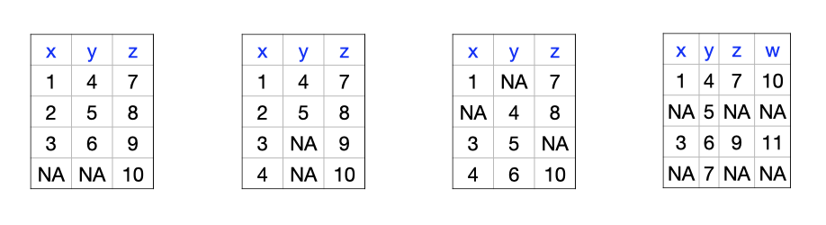

# Value patterns

- Are particular values in one column associated with missing values in another?

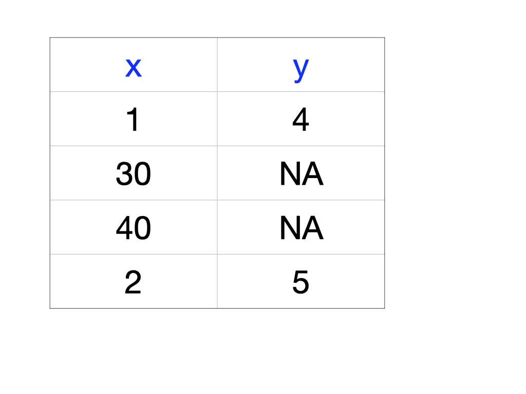

# Sample dataset with missing values

```r
library(tidyverse)
# Add NAs to mtcars dataset
set.seed(5702)
mycars <- mtcars
mycars[,"gear"] <- NA
mycars[10:20, 3:5] <- NA
for (i in 1:10) mycars[sample(32,1), sample(11,1)] <- NA
```

# Row / column missing patterns

## Missing values by column

```r
colSums(is.na(mycars)) %>%
  sort(decreasing = TRUE)
```

```
## gear disp   hp drat   am  cyl qsec   vs  mpg   wt carb
##   32   12   12   11    3    1    1    1    0    0    0
```

# Row / column missing patterns

## Missing values by row

```r
rowSums(is.na(mycars)) %>%
  sort(decreasing = TRUE)
```

```
##          Merc 450SE         Merc 450SLC Lincoln Continental            Fiat 128
##                   5                   5                   5                   5
##            Merc 280           Merc 280C          Merc 450SL  Cadillac Fleetwood
##                   4                   4                   4                   4
##   Chrysler Imperial         Honda Civic      Toyota Corolla        Lotus Europa
##                   4                   4                   4                   3
##         AMC Javelin           Fiat X1-9           Mazda RX4       Mazda RX4 Wag
##                   2                   2                   1                   1
##          Datsun 710      Hornet 4 Drive   Hornet Sportabout             Valiant
##                   1                   1                   1                   1
##          Duster 360           Merc 240D            Merc 230       Toyota Corona
##                   1                   1                   1                   1
##    Dodge Challenger          Camaro Z28    Pontiac Firebird       Porsche 914-2
##                   1                   1                   1                   1
##      Ford Pantera L        Ferrari Dino       Maserati Bora          Volvo 142E
##                   1                   1                   1                   1
```

# Row / column missing patterns

## heatmap

`geom_tile()`

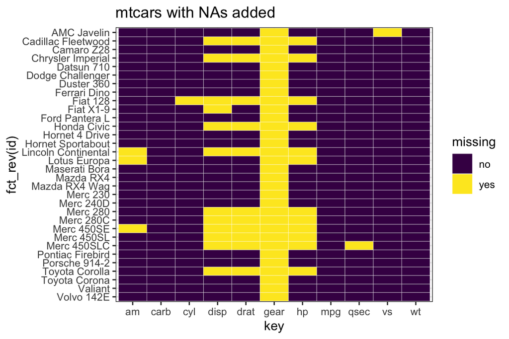

# Row / column missing patterns

## heatmap

`mi::missing_data.frame()`

```r
library(mi)
x <- missing_data.frame(mycars)
```

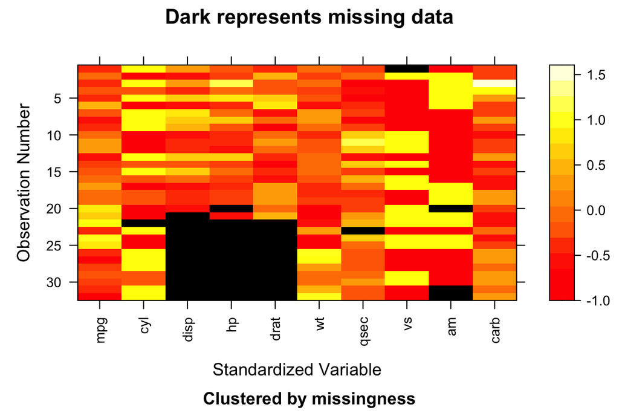

```r
image(x)
```

(gear not shown since all are missing)

# Row / column missing patterns

## Missing values by variable

`geom_tile()`

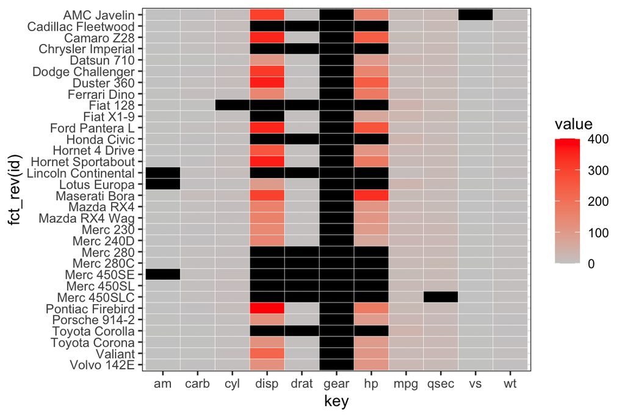

# Row / column missing patterns

## Missing values by variable

`geom_tile()` with standardized variables

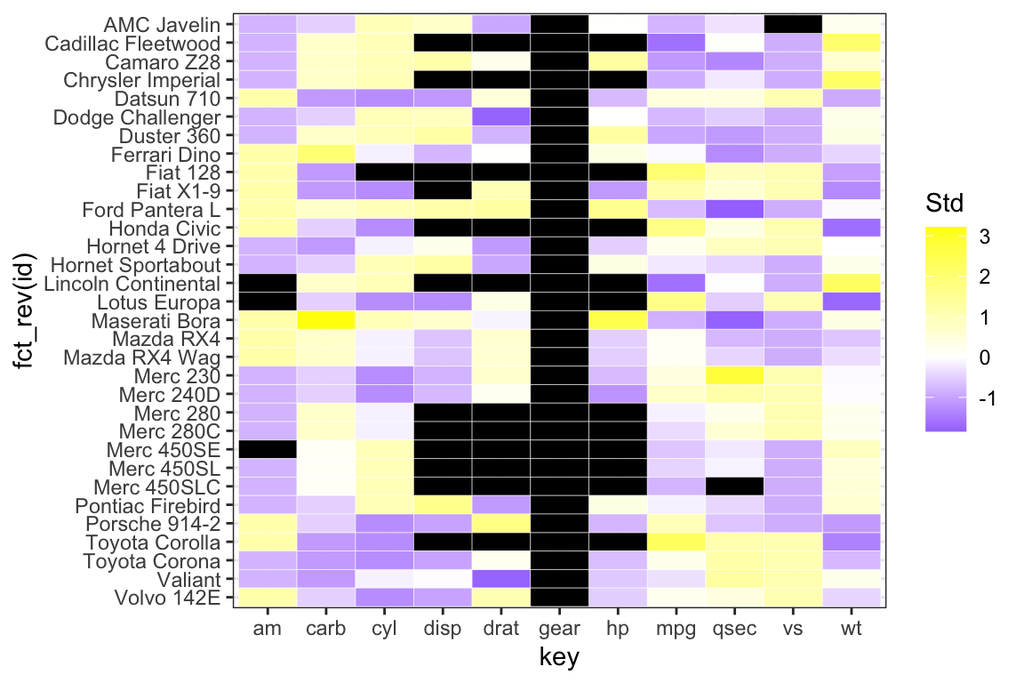

# Row / column missing patterns

## Missing values by variable

reordered by number of missing

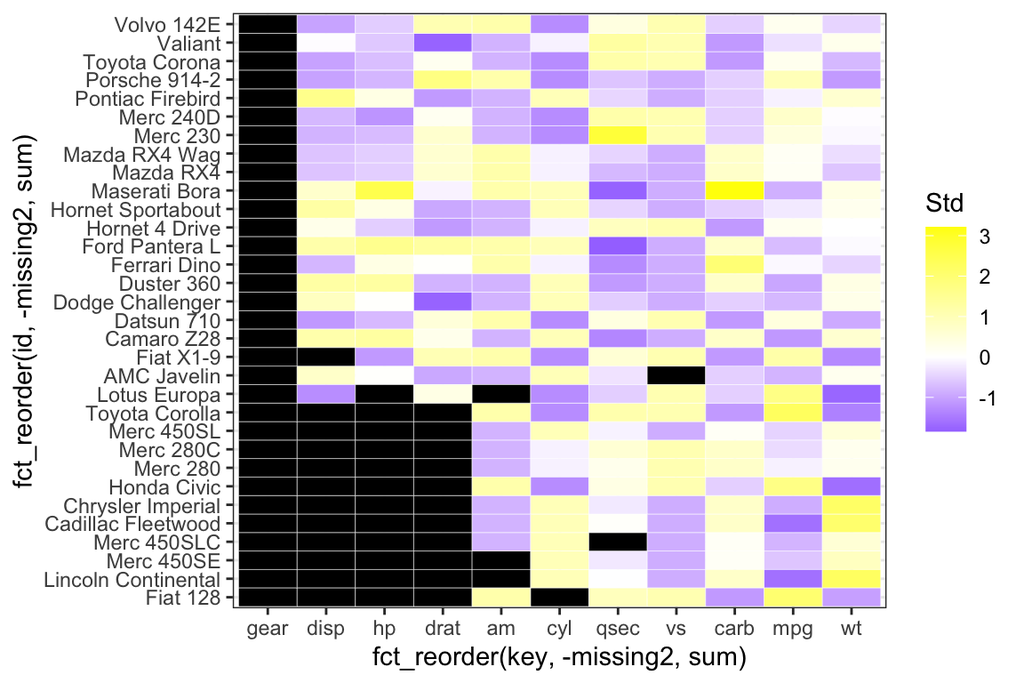

# Row / column missing patterns

### Missing values by variable

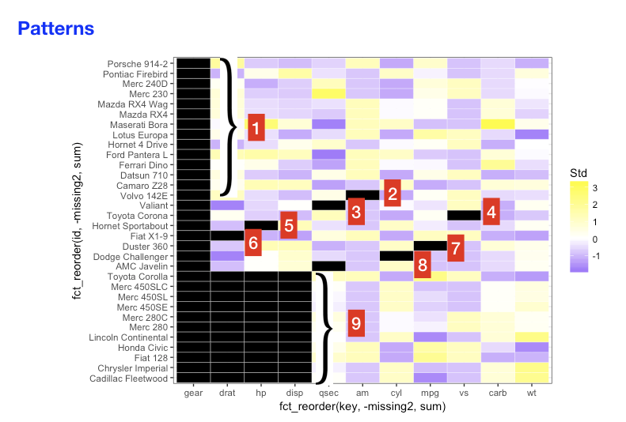

# Row / column missing patterns

### Missing values by variable

missing patterns

```r
x <- mi::missing_data.frame(mycars)
```

```
## NOTE: In the following pairs of variables, the missingness pattern of the second is a subset of the first.
##  Please verify whether they are in fact logically distinct variables.
##      [,1]   [,2]
## [1,] "disp" "drat"
## [2,] "disp" "qsec"
## [3,] "hp"   "drat"
## [4,] "hp"   "qsec"
## [5,] "hp"   "am"
## [6,] "drat" "qsec"
```

```r
class(x)
```

```
## [1] "missing_data.frame"
## attr(,"package")
## [1] "mi"
```

```r
x@patterns
```

```
##  [1] nothing              nothing              nothing
##  [4] nothing              nothing              nothing
##  [7] nothing              nothing              nothing
## [10] disp, hp, drat       disp, hp, drat       disp, hp, drat, am
## [13] disp, hp, drat       disp, hp, drat, qsec disp, hp, drat
## [16] disp, hp, drat, am   disp, hp, drat       cyl, disp, hp, drat
## [19] disp, hp, drat       disp, hp, drat       nothing
## [22] nothing              vs                   nothing
## [25] nothing              disp                 nothing
## [28] hp, am               nothing              nothing
## [31] nothing              nothing
## 8 Levels: nothing vs disp hp, am disp, hp, drat ... cyl, disp, hp, drat
```

```r
levels(x@patterns)
```

```
## [1] "nothing"              "vs"                   "disp"
## [4] "hp, am"               "disp, hp, drat"       "disp, hp, drat, am"
## [7] "disp, hp, drat, qsec" "cyl, disp, hp, drat"
```

```r
summary(x@patterns)
```

```
##              nothing                   vs                 disp
##                   18                    1                    1
##               hp, am       disp, hp, drat   disp, hp, drat, am
##                    1                    7                    2
## disp, hp, drat, qsec  cyl, disp, hp, drat
##                    1                    1
```

# Aggregated missing patterns

(repeated patterns are reduced to one row)

rows and columns sorted by number missing

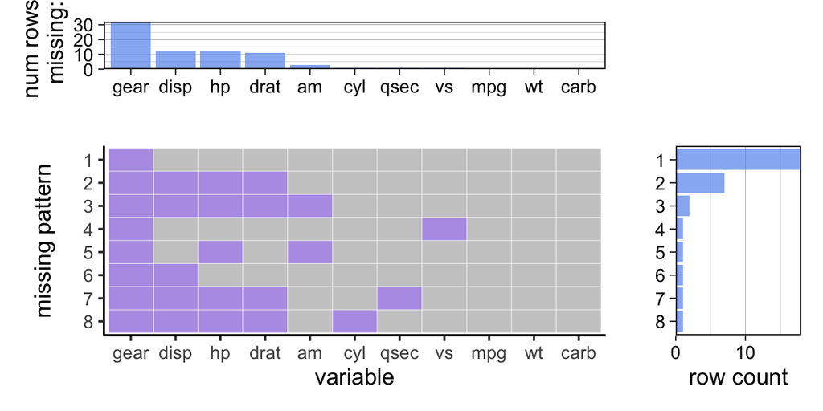

```r
library(redav)
plot_missing(mycars, percent = FALSE)
```

# Aggregated missing patterns (percent)

(repeated patterns are reduced to one row)

rows and columns sorted by percent missing

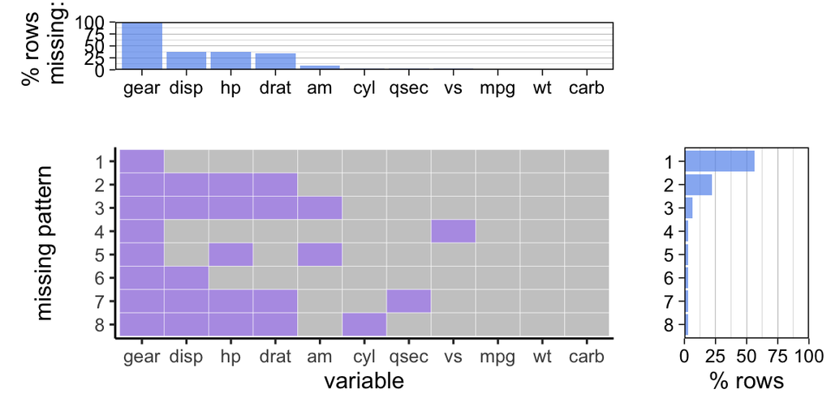

```r
plot_missing(mycars)
```

# NYC School data

| DBN | School Name | Number of Test Takers | Critical Reading Mean | Mathematics Mean | Writing Mean |
| --- | --- | --- | --- | --- | --- |
| 01M292 | Henry Street School for International Studies | 31 | 391 | 425 | 385 |
| 01M448 | University Neighborhood High School | 60 | 394 | 419 | 387 |
| 01M450 | East Side Community High School | 69 | 418 | 431 | 402 |
| 01M458 | SATELLITE ACADEMY FORSYTH ST | 26 | 385 | 370 | 378 |
| 01M509 | CMSP HIGH SCHOOL | NA | NA | NA | NA |
| 01M515 | Lower East Side Preparatory High School | 154 | 314 | 532 | 314 |

```
## [1] 460   6
```

# NYC School data

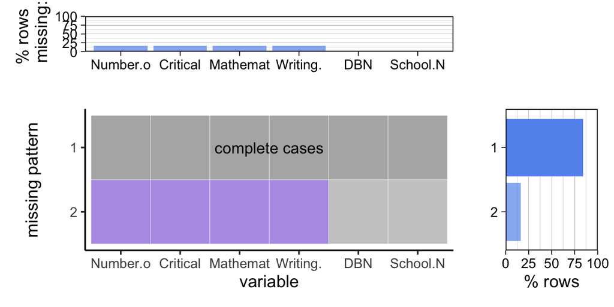

# Value patterns in missing data

- Are missing patterns correlated with values of another variable?
- Are certain value ranges more likely to be missing?
- Or are there no patterns at all?
- (An explanation may not be available within the dataset.)

# NYC School data

Does the proportion of schools with missing data vary by borough?

Data: `SAT2010.csv`

| DBN | School Name | Number of Test Takers | Critical Reading Mean | Mathematics Mean | Writing Mean |
| --- | --- | --- | --- | --- | --- |
| 01M292 | Henry Street School for International Studies | 31 | 391 | 425 | 385 |
| 01M448 | University Neighborhood High School | 60 | 394 | 419 | 387 |
| 01M450 | East Side Community High School | 69 | 418 | 431 | 402 |
| 01M458 | SATELLITE ACADEMY FORSYTH ST | 26 | 385 | 370 | 378 |
| 01M509 | CMSP HIGH SCHOOL | NA | NA | NA | NA |
| 01M515 | Lower East Side Preparatory High School | 154 | 314 | 532 | 314 |

# Missing by borough

| Borough | num_schools | num_na | percent_na |
| --- | --- | --- | --- |
| K | 141 | 32 | 0.23 |
| Q | 73 | 14 | 0.19 |
| M | 111 | 13 | 0.12 |
| X | 124 | 14 | 0.11 |
| R | 11 | 1 | 0.09 |

# Missing by borough

K, Q, M, X, R

Manhattan

Brooklyn

Queens

The Bronx

Staten Island

# Missing by borough

K, Q, M, X, R

Manhattan = New York County

Brooklyn = Kings County

Queens = Queens County

The Bronx = Bronx County

Staten Island = Richmond County

# Missing by borough

K, Q, M, X, R

Manhattan = New York County = “M”

Brooklyn = Kings County = “K”

Queens = Queens County = “Q”

The Bronx = Bronx County = “X”

Staten Island = Richmond County = “R”

# Missing by borough

| Borough | num_schools | num_na | percent_na | BoroughName |
| --- | --- | --- | --- | --- |
| K | 141 | 32 | 0.23 | Brooklyn |
| Q | 73 | 14 | 0.19 | Queens |
| M | 111 | 13 | 0.12 | Manhattan |
| X | 124 | 14 | 0.11 | The Bronx |
| R | 11 | 1 | 0.09 | Staten Island |

# Missing by borough

# Missing by borough and scores

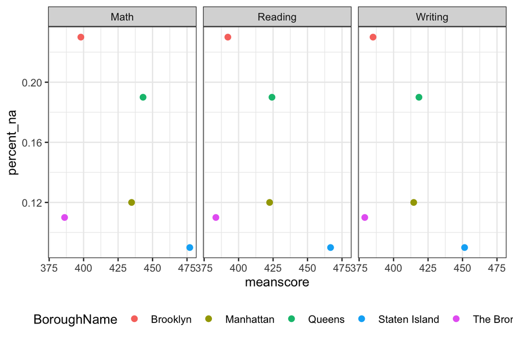

# EXAMPLE: Snowfall

I need to know how much snow fell *per day* in New York State in February 2017, on a county or more detailed level. I know some government agency measures and reports snowfall and puts the data online.

# Snowfall

I need to know how much snow fell *per day* in New York State in February 2017, on a county or more detailed level. I know some government agency measures and reports snowfall and puts the data online.

Source: https://www.ncdc.noaa.gov/snow-and-ice/daily-snow/NY/snowfall/20170201

Accessed: 2017-10-26

[figure not shown]

[figure not shown]

# Number missing by day of month

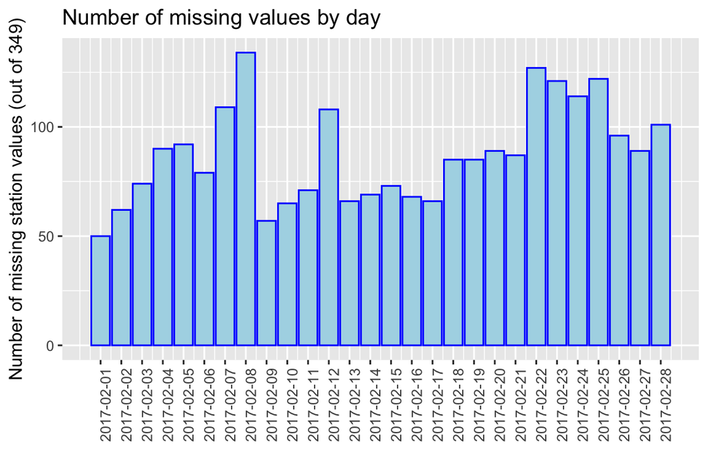

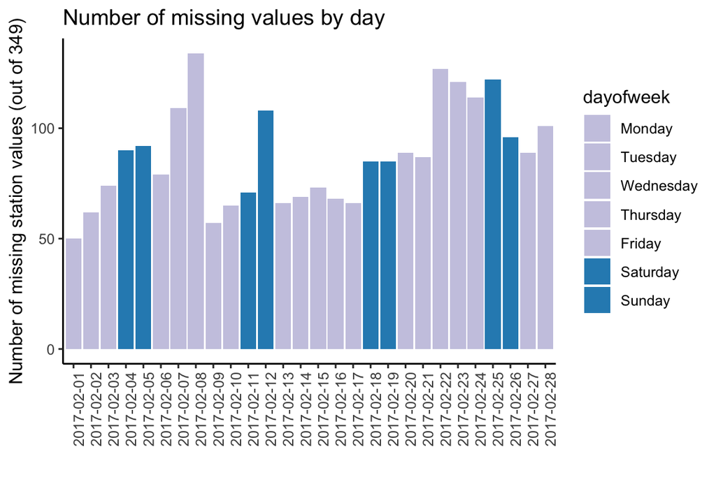

# Number of missing values per day by total snowfall

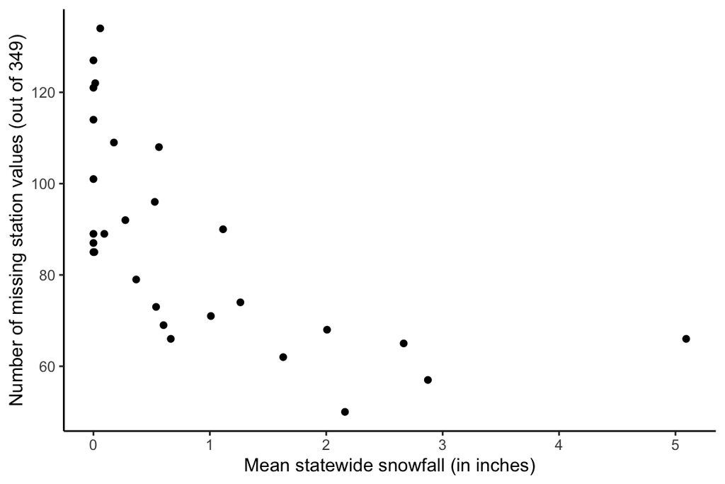